# Series_de_Tiempo_Segundo_Parcial_v2

## Aplicando el auto.arima a la serie 3 Log ((Demanda_electrico))

```r
ARIMA_AUTO_Demanda_electrico_original_ts  <- auto.arima(Demanda_electrico_original_train)
ARIMA_AUTO_Demanda_electrico_original_ts
```

```
## Series: Demanda_electrico_original_train
## ARIMA(0,1,0)
##
## sigma^2 = 48685:  log likelihood = -1363.1
## AIC=2728.2   AICc=2728.22   BIC=2731.5
```

El Auto.Arima, arroja un modelo (0,1,0)

```r
pred_ARIMA_AUTO_Demanda_electrico_original_ts_v_log <- sarima.for(Demanda_electrico_ts_log[1:201], n.ahead=12,0,1,0)
```

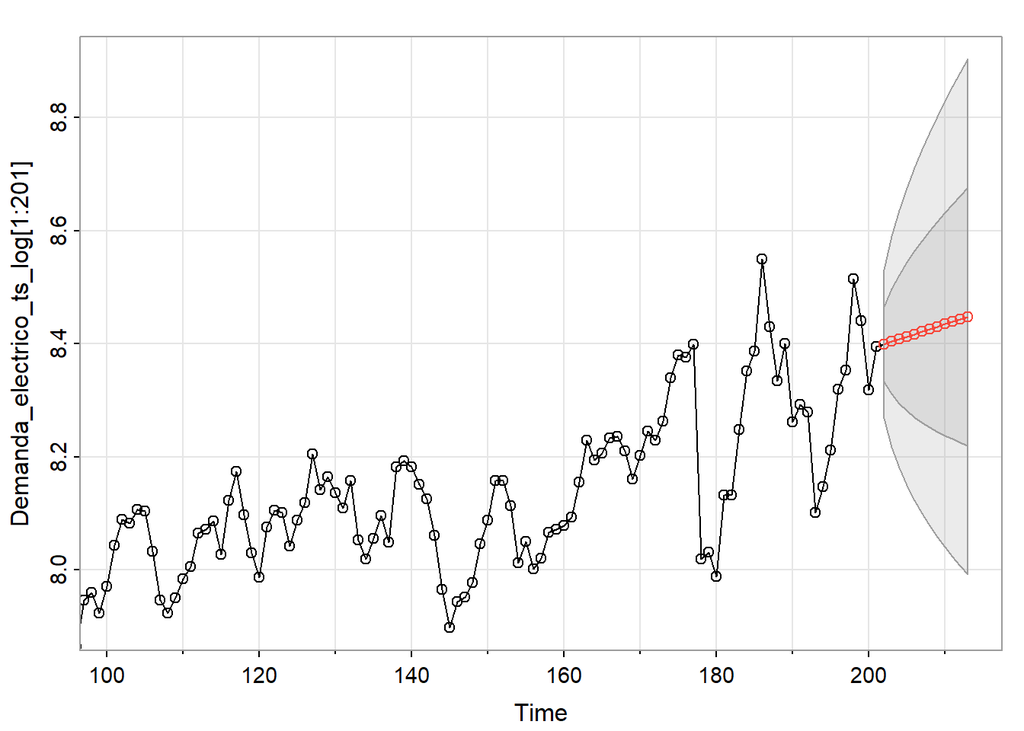

```r
pred_ARIMA_AUTO_Demanda_electrico_original_ts_v_log
```

```
## $pred
## Time Series:
## Start = 202
## End = 213
## Frequency = 1
##  [1] 8.399330 8.403773 8.408216 8.412658 8.417101 8.421543 8.425986 8.430429
##  [9] 8.434871 8.439314 8.443757 8.448199
##
## $se
## Time Series:
## Start = 202
## End = 213
## Frequency = 1
##  [1] 0.06577541 0.09302048 0.11392636 0.13155082 0.14707829 0.16111620
##  [7] 0.17402538 0.18604096 0.19732624 0.20800012 0.21815236 0.22785271
```

#### Calculo de errores del Aplicando el auto.arima a la serie 3 Log ((Demanda_electrico))

```r
accuracy(Demanda_electrico_original_test ,exp(pred_ARIMA_AUTO_Demanda_electrico_original_ts_v_log$pred) )
```

```
##                ME     RMSE      MAE      MPE    MAPE      ACF1 Theil's U
## Test set 856.2851 1006.612 881.0552 18.68322 19.2372 0.6307365  51.78821
```

Aplicando el logaritmo a la serie original el MAPE no mejora con respecto a la serie sin transformar

### Transformando la variable dependiente (LOG(Y)) a la serie 3 (Demanda_electrico) CON DATA ENTRENAMIENTO AISLADA

```r
# Load the TTR package
library(TTR)

Demanda_electrico_ts_log <- log(Demanda_electrico_ts)
```

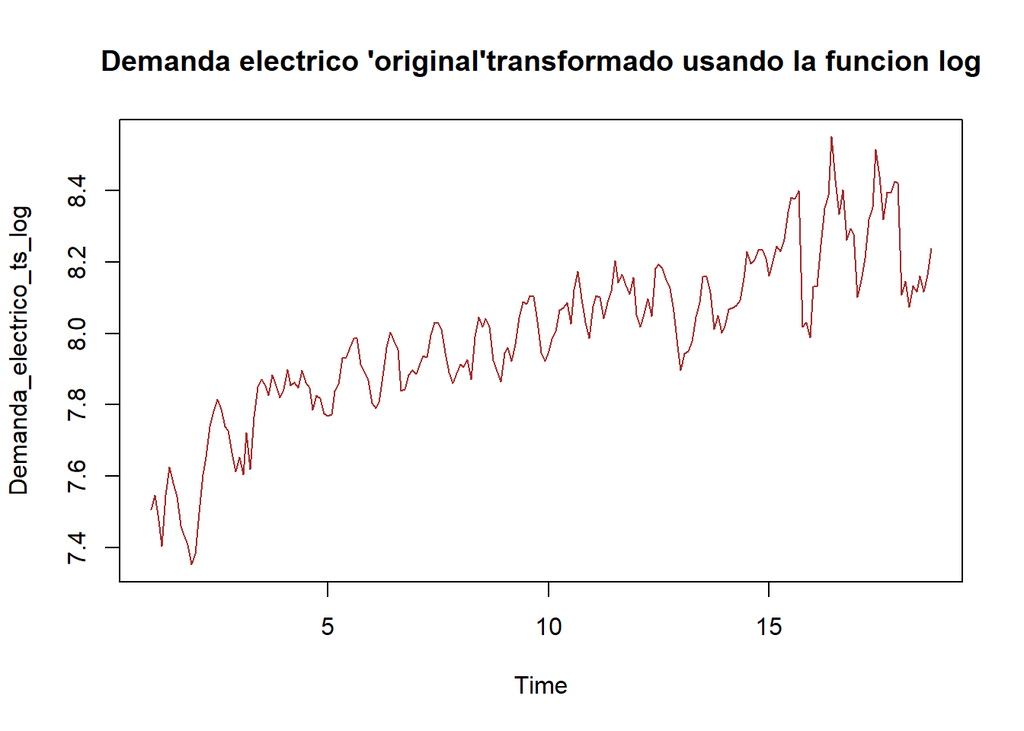

```r
plot(Demanda_electrico_ts_log, col = "brown", main = "Demanda electrico 'original'transformado usando la funcion log")
```

## Aplicando el auto.arima a la serie 3 Log ((Demanda_electrico))

```r
ARIMA_AUTO_Demanda_electrico_original_ts  <- auto.arima(Demanda_electrico_original_train)
ARIMA_AUTO_Demanda_electrico_original_ts
```

```
## Series: Demanda_electrico_original_train
## ARIMA(0,1,0)
##
## sigma^2 = 48685:  log likelihood = -1363.1
## AIC=2728.2   AICc=2728.22   BIC=2731.5
```

El Auto.Arima, arroja un modelo (0,1,0)

```r
pred_ARIMA_AUTO_Demanda_electrico_original_ts_v_train_recortado <- sarima.for(Demanda_electrico_ts_log[1:170], n.ahead=12,0,1,0)
```

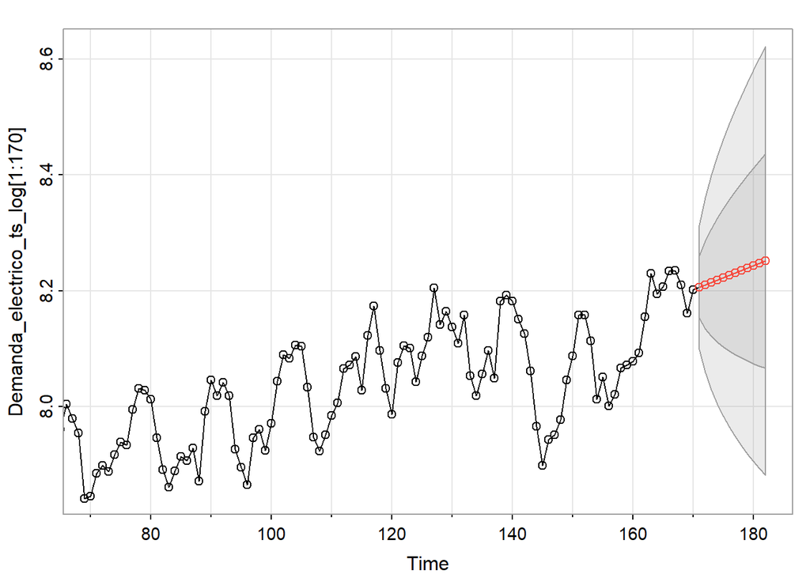

```r
pred_ARIMA_AUTO_Demanda_electrico_original_ts_v_train_recortado
```

```
## $pred
## Time Series:
## Start = 171
## End = 182
## Frequency = 1
##  [1] 8.205940 8.210055 8.214170 8.218285 8.222401 8.226516 8.230631 8.234746
##  [9] 8.238861 8.242976 8.247092 8.251207
##
## $se
## Time Series:
## Start = 171
## End = 182
## Frequency = 1
##  [1] 0.05347896 0.07563067 0.09262827 0.10695792 0.11958259 0.13099616
##  [7] 0.14149202 0.15126134 0.16043687 0.16911532 0.17736964 0.18525655
```

#### Calculo de errores del Aplicando el auto.arima a la serie 3 Log ((Demanda_electrico))

```r
accuracy(Demanda_electrico_original_test ,exp(pred_ARIMA_AUTO_Demanda_electrico_original_ts_v_train_recortado$pred) )
```

```
##               ME     RMSE      MAE      MPE     MAPE      ACF1 Theil's U
## Test set 48.5962 520.3916 462.0067 1.166409 12.40564 0.6227989  32.32865
```

Aplicando el logaritmo a la serie con datos de entrenamiento aislados también se consigue un “buen MAPE” con respecto a este ejercicio que es 12.4 %